# Early gigantic lamniform marks the onset of large-body size in modern shark evolution

#### Full GWS

Relationship between centrum diameter and total length in C. carcharias. Data is based on records from Wintner & Cliff (1999) and Cailliet et al. 1985. The estimated TL along with 95% prediction intervals of the cardabiodontid specimens are added to the graph

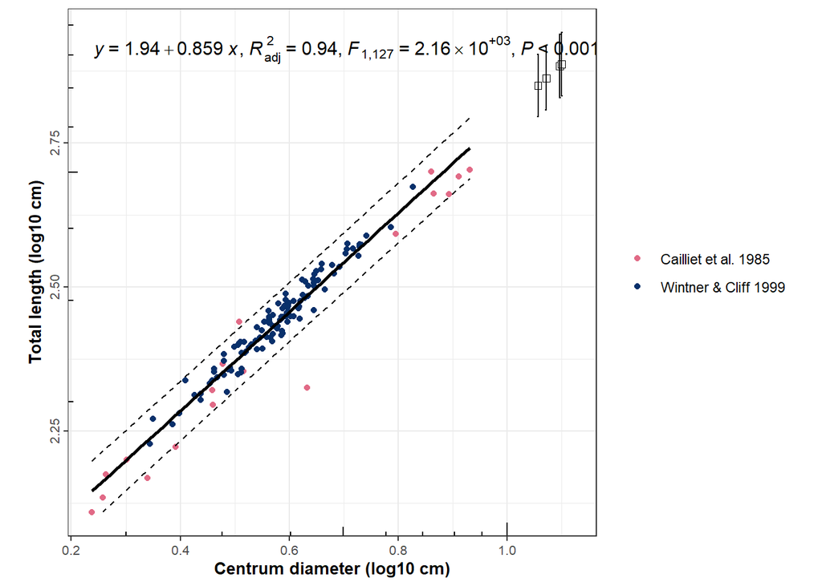

```r
# Prediction intervals.
gws_pi <-
  predict(object = slope_intercept$model[[5]],newdata = data.frame(log_cd = carcharodon_carcharias_complete$log_cd),
          interval = "prediction") |> as.data.frame()
# Plot.
p2 <-
  carcharodon_carcharias_complete |>
  ggplot(mapping = aes(x = log_cd, y = log_tl)) +
  geom_point(aes(colour = reference), shape = 19) +
  annotation_logticks() +
  scale_x_continuous(limits = c(min(carcharodon_carcharias_complete$log_cd),max(aptian_shark$log_cd)+0.02)) +
  scale_y_continuous(limits = c(min(carcharodon_carcharias_complete$log_tl),log10(max(species_prediction$`Carcharodon carcharias`$upr)))) +
  geom_smooth(method = "lm",se = F, colour = "black") +
  ggpmisc::stat_poly_eq(use_label(c("eq", "adj.R2", "f", "p", "n")),
                        size = 4.0,label.x = "left",label.y = "top",
                        color = "black") +
  scale_fill_manual(values =  c("#E16A86","#08306b")) +
  scale_color_manual(values = c("#E16A86","#08306b")) +
  # Prediction intervals.
  geom_line(aes(y = gws_pi[,"lwr"]), col = "black", linetype = "dashed") +
  geom_line(aes(y = gws_pi[,"upr"]), col = "black", linetype = "dashed") +
  # Add fossil predictions to base plot.
  geom_point(data = aptian_shark,mapping = aes(x = log_cd, y = log10(species_prediction$`Carcharodon carcharias`$fit)),
             colour = "black", fill = "white",pch = 22, size = 2) +
  # Labels.
  labs(x = "Centrum diameter (log10 cm)", y = "Total length (log10 cm)") +
  theme_bw() +
  theme(axis.title = element_text(face = "bold",size = 10),
        axis.text = element_text(size = 8),
        axis.text.y = element_text(angle = 90,hjust = 0.5,vjust = 0.5),
        legend.title = element_blank(),
        aspect.ratio = 1)

p3 <- p2 +
  geom_errorbar(data = species_prediction$`Carcharodon carcharias`,
                aes(x = aptian_shark$log_cd,y = log10(fit), ymin = log10(lwr),ymax = log10(upr))
                ,color = "black")

print(p3)
```

```r
# PPE.
complete_gws_ppe <-
  ppe(true = 10^carcharodon_carcharias_complete$log_tl,
      pred = 10^as.vector(fitted(slope_intercept$model[[5]])))
```

```r
data.frame(Reduce(rbind, species_prediction)) |>
  as_tibble() |>
  mutate(taxon = rep(species_fit$species,each = 5)) |>
  mutate(specimens = fct_relevel(specimens,c("NTM P 922-33","NTM P 922-32","NTM P 9382", "NTM P 922-37","NTM P 922-29"))) |>
  as.data.frame() |>
  knitr::kable(caption = "Specimen-level predictions based on extant intraspecific regression equations (see Figure 15).") |>
  kableExtra::kable_styling()
```

Specimen-level predictions based on extant intraspecific regression equations (see Figure 15).

| fit | lwr | upr | specimens | taxon |
| --- | --- | --- | --- | --- |
| 955.3128 | 782.3915 | 1166.4527 | NTM P 922-33 | Alopias pelagicus |
| 960.8450 | 786.7858 | 1173.4110 | NTM P 922-32 | Alopias pelagicus |
| 916.2388 | 751.3181 | 1117.3611 | NTM P 9382 | Alopias pelagicus |
| 893.6249 | 733.3050 | 1088.9950 | NTM P 922-37 | Alopias pelagicus |
| 960.8450 | 786.7858 | 1173.4110 | NTM P 922-29 | Alopias pelagicus |
| 680.9348 | 577.8129 | 802.4608 | NTM P 922-33 | Alopias superciliosus |
| 683.4813 | 579.8936 | 805.5731 | NTM P 922-32 | Alopias superciliosus |
| 662.7976 | 562.9761 | 780.3183 | NTM P 9382 | Alopias superciliosus |
| 652.1758 | 554.2733 | 767.3711 | NTM P 922-37 | Alopias superciliosus |
| 683.4813 | 579.8936 | 805.5731 | NTM P 922-29 | Alopias superciliosus |
| 1621.4056 | 1318.9301 | 1993.2489 | NTM P 922-33 | Alopias vulpinus |
| 1634.0325 | 1328.7240 | 2009.4935 | NTM P 922-32 | Alopias vulpinus |
| 1532.9409 | 1250.1690 | 1879.6721 | NTM P 9382 | Alopias vulpinus |
| 1482.3279 | 1210.7111 | 1814.8804 | NTM P 922-37 | Alopias vulpinus |
| 1634.0325 | 1328.7240 | 2009.4935 | NTM P 922-29 | Alopias vulpinus |
| 522.4046 | 464.4764 | 587.5576 | NTM P 922-33 | Carcharias taurus |
| 524.9973 | 466.5396 | 590.7799 | NTM P 922-32 | Carcharias taurus |
| 504.0303 | 449.8118 | 564.7841 | NTM P 9382 | Carcharias taurus |
| 493.3454 | 441.2489 | 551.5927 | NTM P 922-37 | Carcharias taurus |
| 524.9973 | 466.5396 | 590.7799 | NTM P 922-29 | Carcharias taurus |
| 765.2086 | 674.6441 | 867.9305 | NTM P 922-33 | Carcharodon carcharias |
| 770.4653 | 679.2092 | 873.9823 | NTM P 922-32 | Carcharodon carcharias |
| 728.2427 | 642.5174 | 825.4055 | NTM P 9382 | Carcharodon carcharias |
| 706.9814 | 624.0193 | 800.9731 | NTM P 922-37 | Carcharodon carcharias |
| 770.4653 | 679.2092 | 873.9823 | NTM P 922-29 | Carcharodon carcharias |
| 659.2086 | 548.1126 | 792.8224 | NTM P 922-33 | Cetorhinus maximus |
| 663.0540 | 551.2321 | 797.5598 | NTM P 922-32 | Cetorhinus maximus |
| 632.0530 | 526.0298 | 759.4455 | NTM P 9382 | Cetorhinus maximus |
| 616.3406 | 513.2095 | 740.1962 | NTM P 922-37 | Cetorhinus maximus |
| 663.0540 | 551.2321 | 797.5598 | NTM P 922-29 | Cetorhinus maximus |
| 795.0770 | 716.9864 | 881.6728 | NTM P 922-33 | Isurus oxyrinchus |
| 800.6854 | 722.0237 | 887.9170 | NTM P 922-32 | Isurus oxyrinchus |
| 755.6672 | 681.5831 | 837.8037 | NTM P 9382 | Isurus oxyrinchus |
| 733.0242 | 661.2367 | 812.6054 | NTM P 922-37 | Isurus oxyrinchus |
| 800.6854 | 722.0237 | 887.9170 | NTM P 922-29 | Isurus oxyrinchus |
| 726.7577 | 635.7874 | 830.7444 | NTM P 922-33 | Lamna ditropis |
| 731.6170 | 639.9526 | 836.4110 | NTM P 922-32 | Lamna ditropis |
| 692.5611 | 606.4481 | 790.9017 | NTM P 9382 | Lamna ditropis |
| 672.8717 | 589.5339 | 767.9904 | NTM P 922-37 | Lamna ditropis |
| 731.6170 | 639.9526 | 836.4110 | NTM P 922-29 | Lamna ditropis |
| 840.7268 | 736.1231 | 960.1948 | NTM P 922-33 | Lamna nasus |
| 846.6234 | 741.2607 | 966.9623 | NTM P 922-32 | Lamna nasus |
| 799.2853 | 700.0075 | 912.6431 | NTM P 9382 | Lamna nasus |
| 775.4696 | 679.2458 | 885.3246 | NTM P 922-37 | Lamna nasus |
| 846.6234 | 741.2607 | 966.9623 | NTM P 922-29 | Lamna nasus |
| 444.3957 | 328.8254 | 600.5848 | NTM P 922-33 | Pseudocarcharias kamoharai |
| 446.4493 | 330.1362 | 603.7415 | NTM P 922-32 | Pseudocarcharias kamoharai |
| 429.8222 | 319.4940 | 578.2489 | NTM P 9382 | Pseudocarcharias kamoharai |
| 421.3307 | 314.0329 | 565.2897 | NTM P 922-37 | Pseudocarcharias kamoharai |
| 446.4493 | 330.1362 | 603.7415 | NTM P 922-29 | Pseudocarcharias kamoharai |

Total length estimates of the Darwin Formation cardabiodontid shark. Individual panel corresponds to a unique specimen and show the estimated (back-transformed) values along with 95% prediction intervals generated from our lamniform species-level data subsets.

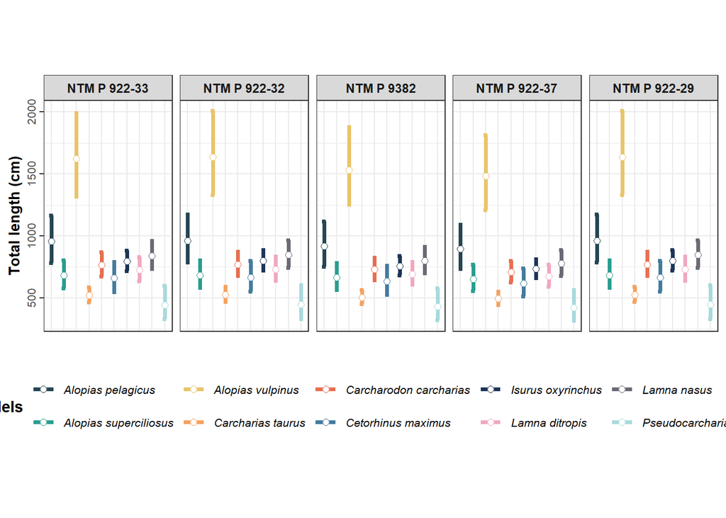

```r
# Based on all lamniform species.
data.frame(Reduce(rbind, species_prediction)) |>
  as_tibble() |>
  mutate(taxon = rep(species_fit$species,each = 5)) |>
  mutate(specimens = fct_relevel(specimens,c("NTM P 922-33","NTM P 922-32","NTM P 9382", "NTM P 922-37","NTM P 922-29"))) |>
  # Plot.
  ggplot(aes(y = taxon, x = fit, colour = taxon)) +
  geom_errorbar(aes(xmin = lwr, xmax = upr),
                width = 0.3, linewidth = 1.3,
                position = position_dodge(width = 0.9)) +
  geom_point(size = 2, fill = "white", shape = 21,
             position = position_dodge(width = 0.9)) +
  scale_fill_manual(values = col_vec) +
  scale_color_manual(values = col_vec) +
  coord_flip() +
  facet_wrap(.~specimens,ncol = 5) +
  labs(x = "Total length (cm)",y = "",
       title = NULL,
       subtitle = NULL,
       color = "Models") +
  theme_bw() +
  theme(title = element_text(face = "bold"),
        axis.title = element_text(face = "bold",size = 10),
        axis.text = element_text(size = 8),
        axis.text.x = element_blank(),
        axis.ticks.x = element_blank(),
        axis.text.y = element_text(angle = 90,hjust = 0.5,vjust = 0.5),
        legend.position = "bottom",
        legend.title = element_text(face = "bold"),
        legend.text = element_text(face = "italic",size = 8),
        plot.title = element_text(face = "bold",size = 12),
        plot.subtitle = element_text(size = 10),
        strip.text = element_text(face = "bold"),
        aspect.ratio = 1.8)
```

#### Lamnidae overview

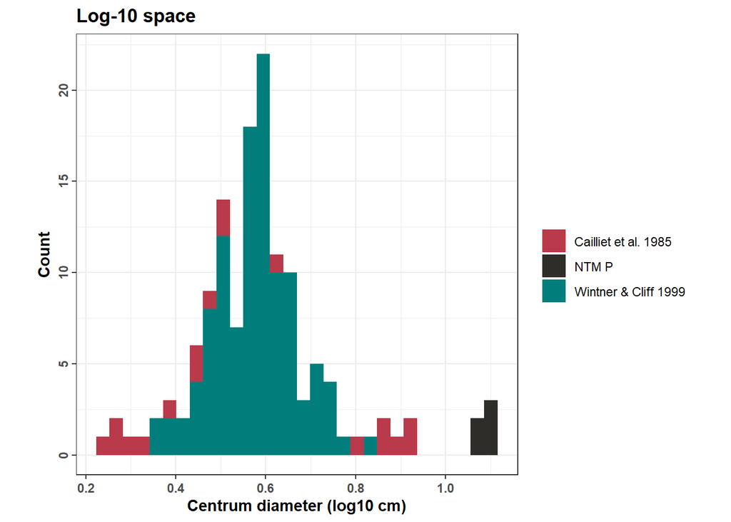

```r
# Plot the log-space of C. carcharias centrum size vs the fossil specimens.
bind_rows(lamnidae_data |>
  filter(species == "Carcharodon carcharias") |>
  select(log_cd,species,reference),aptian_shark |> mutate(species = "NTM P",reference = "NTM P")) |>
  ggplot(mapping = aes(x = log_cd, fill = reference)) +
  geom_histogram(bins = 30) +
  scale_fill_manual(values = c("#B83A4B","#2E2D29","#017E7C")) +
  theme_bw() +
  theme(axis.text.x = element_text(face = "bold"),
        axis.text.y = element_text(face = "bold",angle = 90,hjust = 0.5,vjust = .5),
        axis.title.x = element_text(face = "bold"),
        axis.title.y = element_text(face = "bold"),
        legend.title = element_text(face = "bold"),
        title = element_text(face = "bold"),
        plot.subtitle = element_text(face = "plain"),
        aspect.ratio = 1) +
  labs(title = "Log-10 space",
       subtitle = NULL,
       x = "Centrum diameter (log10 cm)",
       y = "Count", fill = "")
```

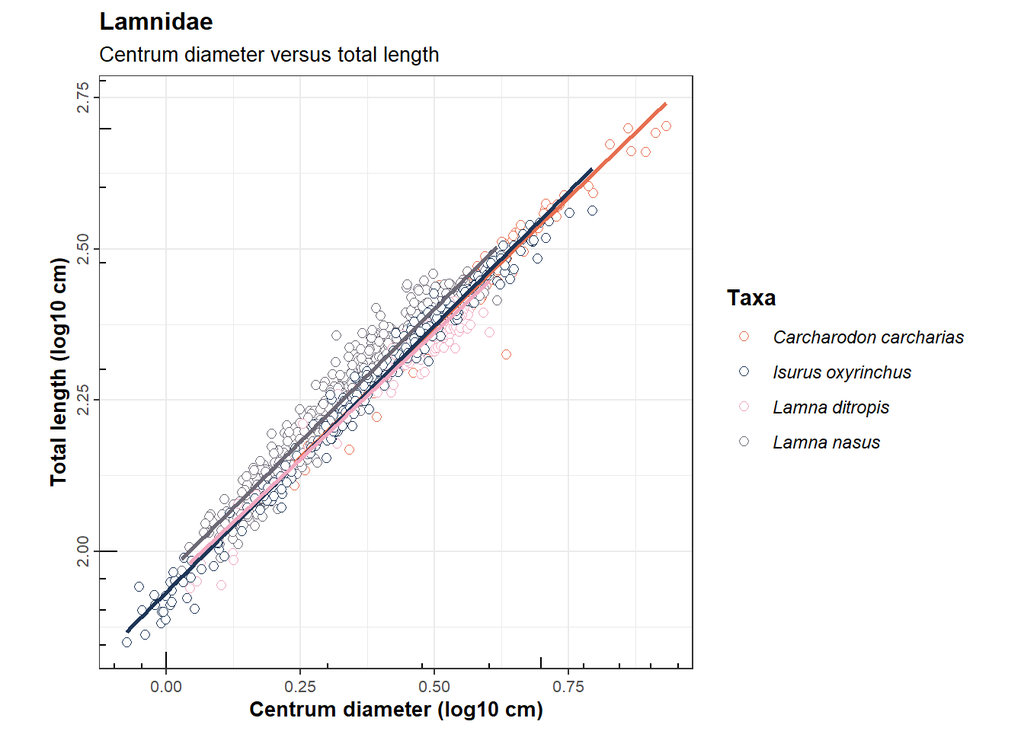

```r
# Check for negative values.

# lamnidae_data |>
#   select(species,contains("log_")) |>
#   filter(log_cd < 0.0)

# Lamnidae species CD-TL relationship.
lamnidae_data |>
  ggplot(aes(x = log_cd, y = log_tl)) +
  geom_point(aes(colour =  species), fill = "white",size = 2, shape = 21) +
  geom_smooth(aes(colour = species),method = "lm",show.legend = F,se = F) +
  annotation_logticks() +
  # Species colors.
  scale_color_manual(values = c("#E76F51","#1D3557", "#F0A8C0FF", "#6D6875")) +
  scale_fill_manual(values =  c("#E76F51","#1D3557", "#F0A8C0FF", "#6D6875")) +
  labs(x = "Centrum diameter (log10 cm)",
       y = "Total length (log10 cm)",
       colour = "Taxa",
       title = "Lamnidae",
       subtitle = "Centrum diameter versus total length") +
  theme_bw() +
  theme(axis.title = element_text(face = "bold",size = 10),
        axis.text = element_text(size = 8),
        axis.text.y = element_text(angle = 90,hjust = 0.5,vjust = 0.5),
        legend.title = element_text(face = "bold"),
        legend.text = element_text(face = "italic"),
        plot.title = element_text(face = "bold",size = 12),
        plot.subtitle = element_text(size = 10),
        aspect.ratio = 1)
```

#### Residual analysis

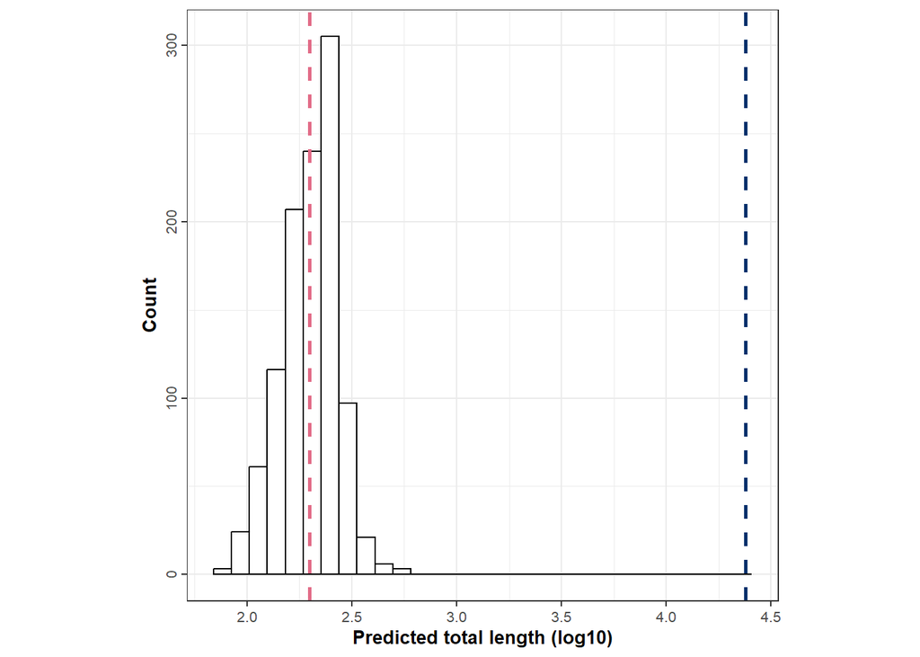

```r
# Linear fit.
lamnidae_model <- lm(log_tl ~ log_cd, lamnidae_data)

# Average Z-score for predicted TL.
zScores = mean((log10(pred_tl$fit) - mean(predict(lamnidae_model)))/sd(predict(lamnidae_model)))

# Plot results.
lamnidae_data |>
  ggplot(mapping = aes(x = predict(lamnidae_model))) +
  geom_histogram(bins = 30, color = "black", fill = "white") +
  #xlim(c(1.949668,4.080516)) +
  geom_vline(xintercept = mean(predict(lamnidae_model)), linewidth = 1, linetype="dashed",colour = "#E16A86") +
  geom_vline(xintercept = zScores, linewidth = 1, linetype="dashed", colour = "#08306b") +
  # Two standard deviations around the mean.
  # geom_vline(xintercept = c((lamnidae_mean - 2 * lamnidae_sd),(lamnidae_mean + 2 * lamnidae_sd)),colour = "black") +
  labs(title = NULL,subtitle = NULL,
       y = "Count",
       x = "Predicted total length (log10)") +
  theme_bw() +
  theme(axis.title = element_text(face = "bold",size = 10),
        axis.text = element_text(size = 8),
        axis.text.y = element_text(angle = 90,hjust = 0.5,vjust = 0.5),
        legend.title = element_text(face = "bold"),
        legend.text = element_text(face = "italic"),
        plot.title = element_text(face = "bold",size = 12),
        plot.subtitle = element_text(size = 10),
        aspect.ratio = 1,legend.position = "none")
```

#### Alopidae overview

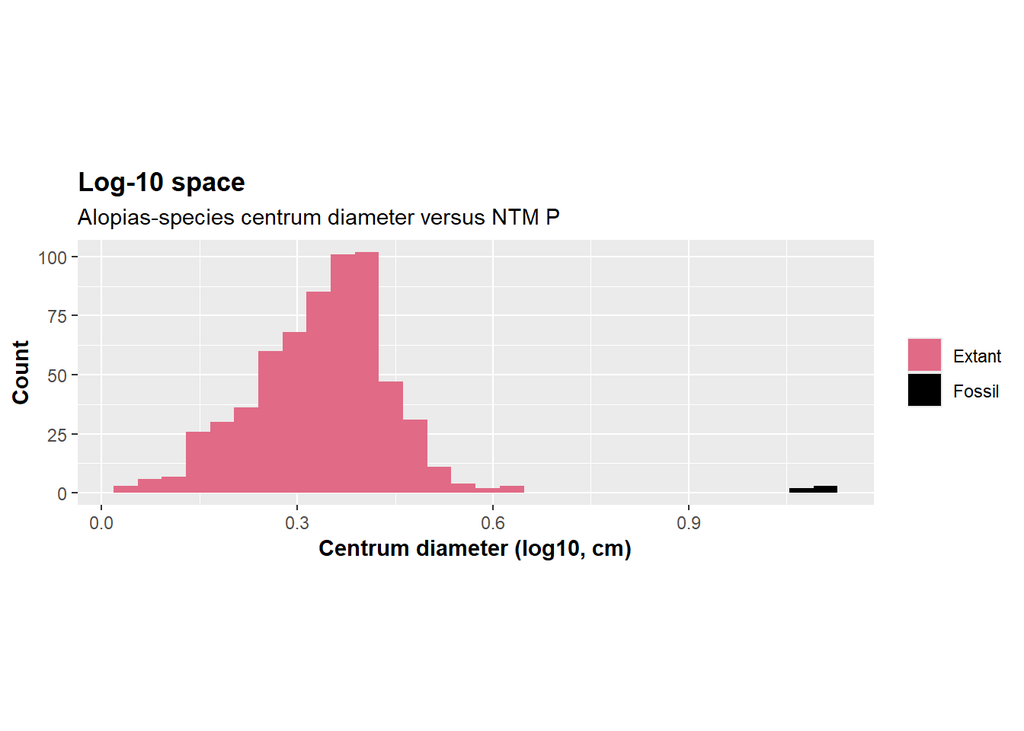

```r
# Alopias log-space and Aptian specimens.
bind_rows(alopiidae_data |> mutate(status = "Extant"),
          aptian_shark |> mutate(status = "Fossil")
) |>
  ggplot(aes(x = log_cd, fill = status)) +
  geom_histogram() +
  scale_fill_manual(values = c("#E16A86","black")) +
  theme(aspect.ratio = 1/3,
        plot.title = element_text(face = "bold"),
        axis.title = element_text(face = "bold")) +
  labs(title = "Log-10 space", fill = NULL,
       subtitle = "Alopias-species centrum diameter versus NTM P",
       x = "Centrum diameter (log10, cm)", y = "Count")
```

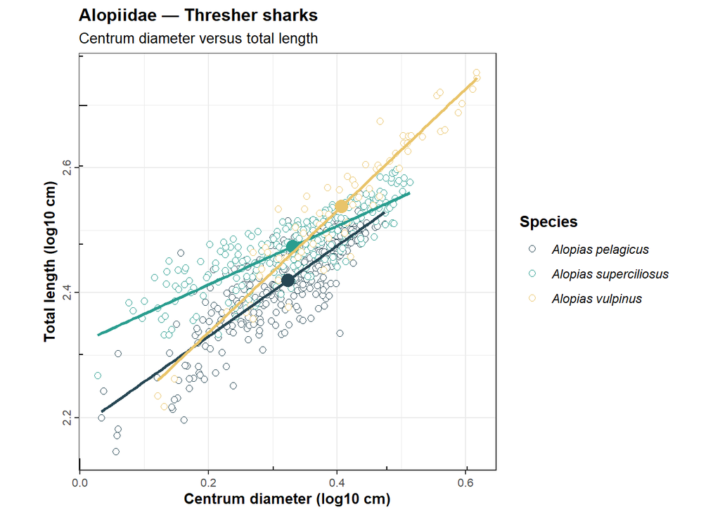

```r
# Only Alopias species.
alopiidae_data |>
  ggplot(aes(x = log_cd, y = log_tl)) +
  geom_point(aes(color = species), fill = "white",size = 2, shape = 21) +
  # Averages.
  geom_point(data = grp_average[c(1:3),], aes(x = log_cd, y = log_tl, colour = species), shape = 19,size = 4,show.legend = F) +
  annotation_logticks() +
  geom_smooth(aes(colour = species),method = "lm",show.legend = F,se = F) +
  scale_color_manual(values = c("#264653", "#2A9D8F", "#E9C46A")) +
  scale_fill_manual(values =  c("#264653", "#2A9D8F", "#E9C46A")) +
  labs(title = "Alopiidae — Thresher sharks",subtitle = "Centrum diameter versus total length",
       y = "Total length (log10 cm)",
       x = "Centrum diameter (log10 cm)", colour = "Species") +
  theme_bw() +
  theme(axis.title = element_text(face = "bold",size = 10),
        axis.text = element_text(size = 8),
        axis.text.y = element_text(angle = 90,hjust = 0.5,vjust = 0.5),
        legend.title = element_text(face = "bold"),
        legend.text = element_text(face = "italic"),
        plot.title = element_text(face = "bold",size = 12),
        plot.subtitle = element_text(size = 10),
        aspect.ratio = 1)
```

### Fossil Predictions (III)

Here we compute **TL** estimates based on our interspecific regression equations.

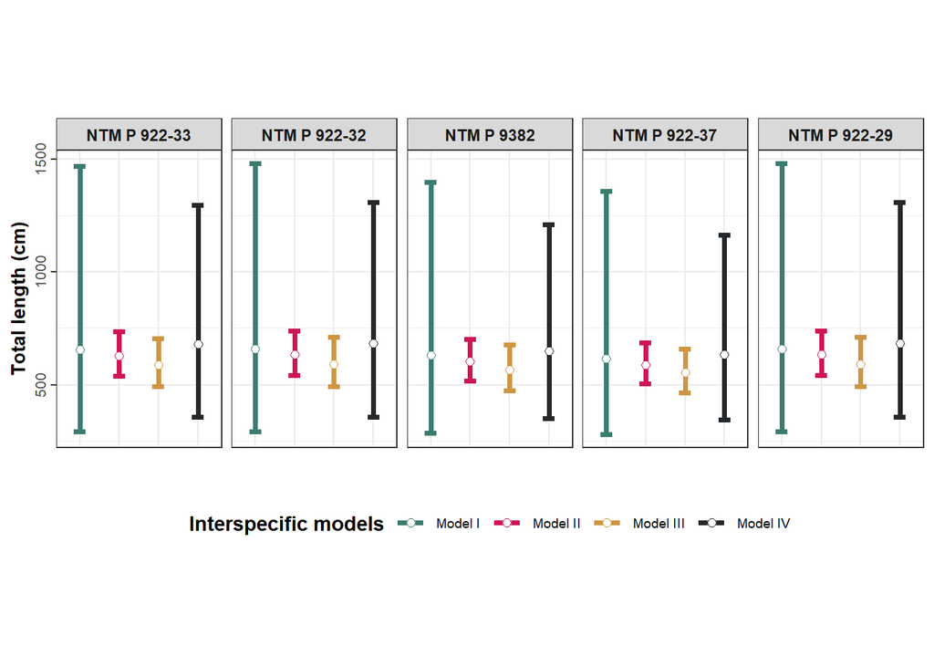

```r
# Predictions on interspecific models.
IS.I <-
  cbind(
  # Model 1.
  10^predict(object = interSM1,newdata = aptian_shark,interval = "prediction"),
  10^predict(object = interSM1,newdata = aptian_shark,interval = "confidence")[,2:3]) |>
  as.data.frame() |>
  unname() |>
  setNames(nm = c("fit",".pred_lower",".pred_upper",".conf_lower",".conf_upper")) |>
  mutate(specimen = c("NTM P 922-33","NTM P 922-32","NTM P 9382", "NTM P 922-37","NTM P 922-29")) |>
  mutate(model = "Model I")

IS.II <-
  cbind(
  # Model 2.
  10^predict(object = interSM2,newdata = aptian_shark,interval = "prediction"),
  10^predict(object = interSM2,newdata = aptian_shark,interval = "confidence")[,2:3]) |>
  as.data.frame() |>
  unname() |>
  setNames(nm = c("fit",".pred_lower",".pred_upper",".conf_lower",".conf_upper")) |>
  mutate(specimen = c("NTM P 922-33","NTM P 922-32","NTM P 9382", "NTM P 922-37","NTM P 922-29")) |>
  mutate(model = "Model II")

IS.III <-
  cbind(
  # Model 3.
  10^predict(object = interSM3,newdata = aptian_shark,interval = "prediction"),
  10^predict(object = interSM3,newdata = aptian_shark,interval = "confidence")[,2:3]) |>
  as.data.frame() |>
  unname() |>
  setNames(nm = c("fit",".pred_lower",".pred_upper",".conf_lower",".conf_upper")) |>
  mutate(specimen = c("NTM P 922-33","NTM P 922-32","NTM P 9382", "NTM P 922-37","NTM P 922-29")) |>
  mutate(model = "Model III")

IS.IIII <-
  cbind(
  # Model 4.
  10^predict(object = interSM4,newdata = aptian_shark,interval = "prediction"),
  10^predict(object = interSM4,newdata = aptian_shark,interval = "confidence")[,2:3]) |>
  as.data.frame() |>
  unname() |>
  setNames(nm = c("fit",".pred_lower",".pred_upper",".conf_lower",".conf_upper")) |>
  mutate(specimen = c("NTM P 922-33","NTM P 922-32","NTM P 9382", "NTM P 922-37","NTM P 922-29")) |>
  mutate(model = "Model IV")

# Plot results.
bind_rows(IS.I,IS.II,IS.III,IS.IIII) |>
  mutate(specimen = fct_relevel(specimen,c("NTM P 922-33","NTM P 922-32","NTM P 9382", "NTM P 922-37","NTM P 922-29"))) |>
  # Plot.
  ggplot(aes(y = model, x = fit, colour = model)) +
  geom_errorbar(aes(xmin = .pred_lower, xmax = .pred_upper),
                width = 0.3, linewidth = 1.3,
                position = position_dodge(width = 0.9)) +
  geom_point(size = 2, fill = "white", shape = 21,
             position = position_dodge(width = 0.9)) +
  coord_flip() +

  scale_fill_manual(values =  c("#3B7C70FF","#D01556FF","#CE9642FF","#25282AFF")) +
  scale_color_manual(values = c("#3B7C70FF","#D01556FF","#CE9642FF","#25282AFF")) +
  facet_wrap(.~specimen,ncol = 5) +
  labs(x = "Total length (cm)",y = "",
       title = NULL,
       subtitle = NULL,
       color = "Interspecific models") +
  theme_bw() +
  theme(title = element_text(face = "bold"),
        axis.title = element_text(face = "bold",size = 10),
        axis.text = element_text(size = 8),
        axis.text.x = element_blank(),
        axis.ticks.x = element_blank(),
        axis.text.y = element_text(angle = 90,hjust = 0.5,vjust = 0.5),
        legend.position = "bottom",
        legend.title = element_text(face = "bold"),
        legend.text = element_text(size = 7),
        plot.title = element_text(face = "bold",size = 12),
        plot.subtitle = element_text(size = 10),
        strip.text = element_text(face = "bold"),
        aspect.ratio = 1.8)
```

```r
# PPE.

# intervals(xvar = IS.I$fit)[c(1,7:8)]
# intervals(xvar = IS.II$fit)[c(1,7:8)]
# intervals(xvar = IS.III$fit)[c(1,7:8)]
# intervals(xvar = IS.IIII$fit)[c(1,7:8)]
```

## Mesozoic data

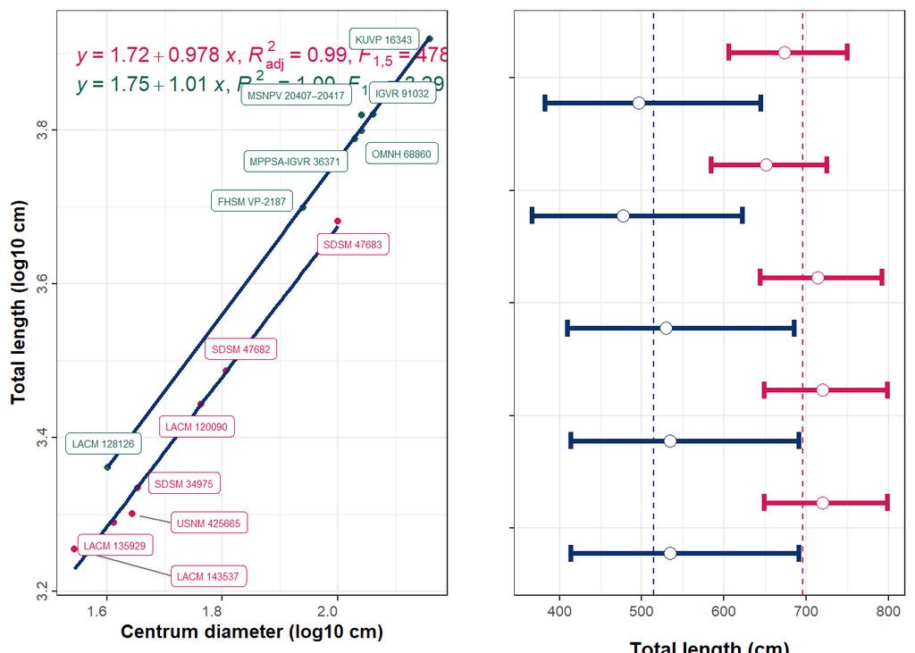

```r
# Minor feature engineering.
mesozoic_data_subset <-
  mesozoic_data |>
  mutate(log_cd = log10(centrum_diameter),
         log_tl = log10(total_length)) |>
  filter(species != "Cardabiodon ricki")

# Visualize.
meso_01 <-
  mesozoic_data_subset |>
  ggplot(aes(x = log_cd, y = log_tl, color = family)) +
  geom_point() +
  geom_smooth(aes(fill = family),method = "lm", se = F, color = "#08306b") +
  scale_fill_manual(values =  c("#D01556FF","#175E54")) +
  scale_color_manual(values = c("#D01556FF","#175E54")) +
  stat_poly_eq(use_label(c("eq", "adj.R2", "f", "p", "n")),
               size = 4.0,label.x = "left",label.y = "top") +
  # geom_smooth(method = "rlm", se = FALSE, color = "#027EB6",linetype = 2) +
  labs(x = "Centrum diameter (log10 cm)",
       y = "Total length (log10 cm)") +
  geom_label_repel(aes(label = label),size = 2,
                  box.padding = unit(0.35, "lines"),
                  point.padding = unit(0.5, "lines"),
                  segment.color = 'grey50') +
  # facet_wrap(.~family, scale = "free") +
  theme_bw() +
  theme(title = element_text(face = "bold"),
        axis.title = element_text(face = "bold",size = 10),
        axis.text = element_text(size = 8),
        axis.text.x = element_text(hjust = 1,vjust = 1),
        axis.text.y = element_text(angle = 90,hjust = 0.5,vjust = 0.5),
        legend.title = element_text(face = "bold"),
        legend.position = "none",
        aspect.ratio = 1.5)

# Fit linear model.
stem_fit_01 <- lm(log_tl ~ log_cd, data = mesozoic_data_subset)
stem_fit_02 <- lm(log_tl ~ log_cd, data = mesozoic_data_subset,subset = mesozoic_data_subset$family == "non-Anacoracidae")
# stem_fit |> summary()

# OLS prediction.
pred_stem_ols_01 <-
  10^predict(stem_fit_01, newdata = aptian_shark,interval = "prediction",level = 0.95) |>
  bind_cols(specimen = c("NTM P 922-33","NTM P 922-32","NTM P 9382", "NTM P 922-37","NTM P 922-29")) |>
  as.data.frame() |>
  add_column(status = rep("OLS: complete data",5))

pred_stem_ols_02 <-
  10^predict(stem_fit_02, newdata = aptian_shark,interval = "prediction",level = 0.95) |>
  bind_cols(specimen = c("NTM P 922-33","NTM P 922-32","NTM P 9382", "NTM P 922-37","NTM P 922-29")) |>
  as.data.frame() |>
  add_column(status = rep("OLS: non-Anacoracidae",5))

# Compare OLS vs RLM prediction results.
stem_all_predictions <-
  bind_rows(pred_stem_ols_01,pred_stem_ols_02) |>
  reshape::melt(c("fit","lwr","upr","specimen","status"))

# Plot.
meso_02 <- stem_all_predictions |>
  ggplot(aes(y = specimen, x = fit, colour = status)) +
  geom_errorbar(aes(xmin = lwr, xmax = upr),
                width = 0.3, linewidth = 1.3,
                position = position_dodge(width = 0.9)) +
  geom_point(size = 3, fill = "white", shape = 21,
             position = position_dodge(width = 0.9)) +
  scale_fill_manual(values =  c("#08306b","#D01556FF")) +
  scale_color_manual(values = c("#08306b","#D01556FF")) +
  geom_vline(xintercept = c(514.3853,695.5629), col = c("#08306b","#D01556FF"), linetype = c(2,2)) +
  theme_bw() +
  labs(x = "Total length (cm)",y = "", color = "Model") +
  theme(legend.position = "none",
        title = element_text(face = "bold"),
        plot.subtitle = element_text(face = "plain"),
        strip.text = element_blank(),
        axis.text.y = element_blank(),
        axis.text = element_text(size = 8),
        axis.title.x = element_text(vjust = -3),
        plot.caption = element_text(hjust = 0),
        aspect.ratio = 1.5)
  # facet_wrap(~factor(specimen,c("NTM P922-32","NTM P922-29",
  #                               "NTM P 922-37","NTM P 922-33")),scales = "free_y",ncol = 2)

ggarrange(meso_01,meso_02,ncol = 2,align = "hv")
```

## Phylogenetic least squares

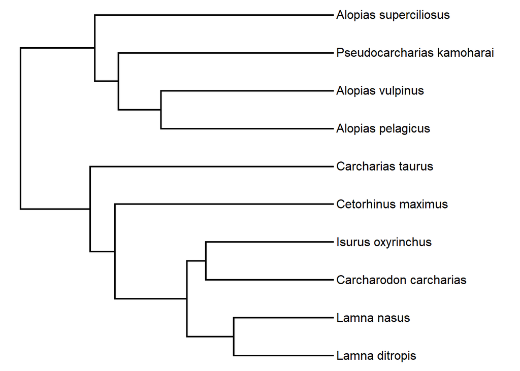

```r
# Genetic Data Only Tree.
shark_tree <- readNexus(file = "phylogeny/500treePLtrees.nex")
# MCC Tree.
mcc_tree <- maxCladeCred(x = shark_tree,rooted = T) # Genetic Data Only Trees.

grp_average_clean <- data.frame(CD = setNames(grp_average$log_cd,gsub(" ", "_", grp_average$species)),
                                TL = setNames(grp_average$log_tl,gsub(" ", "_", grp_average$species)),
                                species = gsub(" ", "_", grp_average$species))

# layout(matrix(c(1:2),nrow = 2),respect = T)

# Drop tips.
lamn_tree <- treedata(phy = mcc_tree,data = grp_average_clean, warnings = FALSE)$phy
plotTree(ladderize(lamn_tree))
```

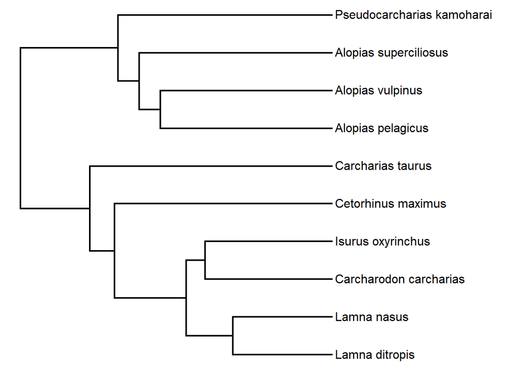

```r
# Alternative lamniform MCC topology.
modified_tree <- readNexus(file = "phylogeny/mccTree_alopias.nex") # Make Alopias monophyletic.
# Drop-tips.
modified_lamn <- treedata(phy = modified_tree,data = grp_average_clean, warnings = FALSE)$phy

# Calculates distances to the root
# adephylo::distRoot(modified_lamn)

# All tips should be 115.9955 Ma from the root to be ultrametric
# A. superciliosus needs to reduce by 132.6635 - 115.9955 = 16.668
modified_lamn$edge.length[6] <- 88.436256 - 16.668

plotTree(ladderize(modified_lamn)) # re-check tree
```

```r
distRoot(modified_lamn) # re-calculates distances to the root, should all be equal
```

```
         Alopias_pelagicus      Alopias_superciliosus
                  115.9955                   115.9955
          Alopias_vulpinus          Carcharias_taurus
                  115.9955                   115.9955
    Carcharodon_carcharias         Cetorhinus_maximus
                  115.9955                   115.9955
         Isurus_oxyrinchus             Lamna_ditropis
                  115.9955                   115.9955
               Lamna_nasus Pseudocarcharias_kamoharai
                  115.9955                   115.9955
```

```r
# PGLS (via RRPP).
grp_pgls <- rrpp.data.frame(CD = setNames(grp_average_clean$CD,gsub(" ", "_", grp_average_clean$species)),
                            TL = setNames(grp_average_clean$TL,gsub(" ", "_", grp_average_clean$species)),
                            species = gsub(" ", "_", grp_average_clean$species),
                            ecology = c(rep("macrophagous",5),rep("filter-feeding",1),rep("macrophagous",4)))

grp_pgls$CovA <- vcv.phylo(lamn_tree)
grp_pgls$CovB <- vcv.phylo(modified_lamn) # Modified.

# Fit model for the first topology.
pgls_shark <- lm.rrpp(f1 = TL ~ CD,data = grp_pgls, Cov = grp_pgls$CovA,  print.progress = FALSE)
anova(pgls_shark)
```

```
Analysis of Variance, using Residual Randomization
Permutation procedure: Randomization of null model residuals
Number of permutations: 1000
Estimation method: Generalized Least-Squares (via OLS projection)
Sums of Squares and Cross-products: Type I
Effect sizes (Z) based on F distributions

          Df        SS        MS     Rsq      F      Z Pr(>F)
CD         1 0.0033993 0.0033993 0.84358 43.144 3.6063  0.002 **
Residuals  8 0.0006303 0.0000788 0.15642
Total      9 0.0040297
---
Signif. codes:  0 '***' 0.001 '**' 0.01 '*' 0.05 '.' 0.1 ' ' 1

Call: lm.rrpp(f1 = TL ~ CD, data = grp_pgls, Cov = grp_pgls$CovA, print.progress = FALSE)
```

```r
nonPhylo_shark <- lm.rrpp(f1 = TL ~ CD,data = grp_pgls,  print.progress = FALSE)

# model.comparison(pgls_shark,nonPhylo_shark,type = "logLik") # PGLS is better.

# Fit model for the second topology.
pgls_shark_02 <- lm.rrpp(f1 = TL ~ CD,data = grp_pgls, Cov = grp_pgls$CovB,  print.progress = FALSE)

# Generalized Least-Squares (via OLS projection)
# tree_ggplot <-
#   ggtree(lamn_tree) +
#   geom_tiplab(as_ylab=TRUE, color='black') +
#   theme(aspect.ratio = 1)

pgls_plot <-
  data.frame(cd = grp_average_clean$CD,
           tl = grp_average_clean$TL,
           labels = grp_average_clean$species) |>
  ggplot(aes(x = cd,y = tl)) +
  geom_point(fill = "black",size = 2, shape = 21) +
  geom_text_repel(aes(label = labels),
                  size = 4,
                  box.padding = unit(0.35, "lines"),
                  point.padding = unit(0.3, "lines")) +
  labs(y = "Average total length (log10)",
       x = "Average centrum diameter (log10)") +
  annotation_logticks() +
  geom_abline(intercept = coef(pgls_shark_02)[1], slope = coef(pgls_shark_02)[2], color = "#175E54", linetype = 2) +
  geom_abline(intercept = coef(pgls_shark)[1], slope = coef(pgls_shark)[2], color = "#B2182B") +
  geom_abline(intercept = coef(nonPhylo_shark)[1], slope = coef(nonPhylo_shark)[2], color = "blue") +
  theme_bw() +
  theme(axis.title = element_text(face = "bold",size = 10),
        axis.text = element_text(size = 8),
        axis.text.y = element_text(angle = 90,hjust = 0.5,vjust = 0.5),
        legend.position = "none",
        legend.title = element_text(face = "bold"),
        legend.text = element_text(face = "italic"),
        plot.title = element_text(face = "bold",size = 12),
        plot.subtitle = element_text(size = 10),
        aspect.ratio = 1)
```

### Phylogenetic signal

```r
# Signal including Blombergs K and Effect Size.

# zCD <- geomorph::physignal.z(A = setNames(grp_average_clean[,"CD"],gsub(" ","_",grp_average_clean$species)),
#                              phy = lamn_tree,lambda = "front", iter=999)[1]
#
# zTL <- geomorph::physignal.z(A = setNames(grp_average_clean[,"TL"],gsub(" ","_",grp_average_clean$species)),
#                              phy = lamn_tree,lambda = "front", iter=999)[1]
#
# set.seed(1)

# cbind(
  # Blomberg K.
#   phytools::phylosig(tree = lamn_tree,
#                      x = setNames(grp_average_clean[,"CD"],gsub(" ","_",grp_average_clean$species)),
#                      test = T)[1:2] |> unlist(),
#   phytools::phylosig(tree = lamn_tree,
#                      x = setNames(grp_average_clean[,"TL"],gsub(" ","_",grp_average_clean$species)),
#                      test = T)[1:2] |> unlist()
# ) |>
#   magrittr::set_colnames(c("CD", "TL")) |>
#   as.data.frame() |>
#   add_row(CD = unlist(unname(zCD)), TL = unlist(unname(zTL))) |>
#   t() |>
#   magrittr::set_colnames(c("K", "P","Z")) |>
#   knitr::kable(caption = "Phylogenetic signal in CD and TL") |>
#   kableExtra::kable_styling()

# Sensitivity test (exclude Alopias species)
# exclude_alopias_d <- grp_average_clean[c(4:10),]
# exclude_alopias_t <- treedata(phy = mcc_sgTree,data = exclude_alopias_d, warnings = FALSE)$phy

# Effect size.
# zCD_alopias <- geomorph::physignal.z(A = setNames(exclude_alopias_d[,"CD"],gsub(" ","_",exclude_alopias_d$species)),
#                              phy = exclude_alopias_t,lambda = "front", iter=999)[1]
#
# zTL_alopias <- geomorph::physignal.z(A = setNames(exclude_alopias_d[,"TL"],gsub(" ","_",exclude_alopias_d$species)),
#                              phy = exclude_alopias_t,lambda = "front", iter=999)[1]
#
# set.seed(2)

# Blomberg K.
# cbind(
#   phytools::phylosig(tree = exclude_alopias_t,
#                      x = setNames(exclude_alopias_d[,"CD"],gsub(" ","_",exclude_alopias_d$species)),
#                      test = T)[1:2] |> unlist(),
#   phytools::phylosig(tree = exclude_alopias_t,
#                      x = setNames(exclude_alopias_d[,"TL"],gsub(" ","_",exclude_alopias_d$species)),
#                      test = T)[1:2] |> unlist()
# )
```

## Modern body-size ranges

```r
# Body size ranges.
size_trait <-
  openxlsx::read.xlsx(xlsxFile = "data/lamniformes-body-ranges.xlsx") |>
  mutate(min = as.numeric(min),
         max = as.numeric(max))

rownames(size_trait) <- size_trait$species

bzR <- data.frame(min = setNames(size_trait$min, size_trait$species),
                  max = setNames(size_trait$max, size_trait$species),
                  species = size_trait$species)

# Complete lamniform tree.
# lamniformTree <- geiger::treedata(phy = mcc_sgTree,data = bzR, warnings = FALSE)$phy # 14 lamnifom taxa

xe <- c(setNames(size_trait$min, size_trait$species),
        setNames(size_trait$max, size_trait$species)
        )

xt <- xe[order(names(xe))][-c(25:26)] # Remove Odontaspis_ferox (Missing from tree)

# Plot.
# par(mfrow=c(1,2))
# plotTree(lamniformTree,mar=c(5.1,1.1,2.1,0.1)); axisPhylo(1)
# par(mar=c(5.1,0.1,2.1,1.1))
# boxplot(xt~factor(names(xt),levels=lamniformTree$tip.label),horizontal=TRUE,xlab = "Body size (cm)",
#     axes=F,xlim=c(1,Ntip(lamniformTree)))
#
# axis(1)
```

## GWS vertebrae counts

Make sure you note the number of verts was only the total amount we sampled, they had more verts but we stopped sampling around the caudal peduncle. You might want to make sure that is clear.

$$Y_i \sim \text{Poisson}(\lambda_i)$$

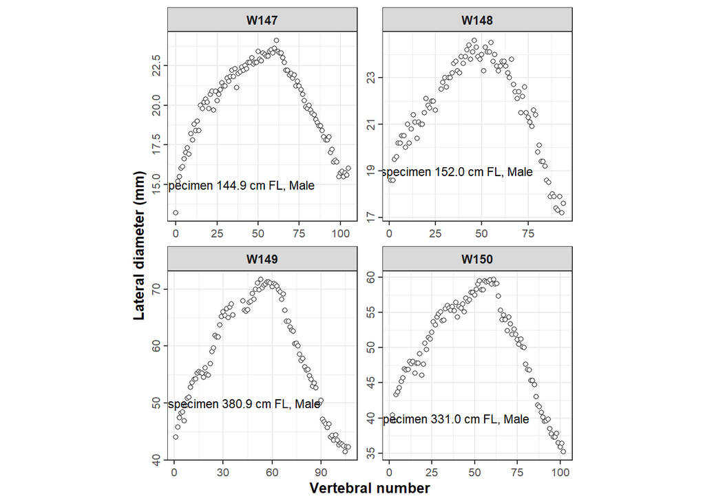

```r
# Plot data
gws_long_format <-
  bind_rows(natanson_data[[3]],natanson_data[[4]],
              natanson_data[[5]],natanson_data[[6]]) |>
  janitor::clean_names()

column_label <- tibble(
  vertebrae = Inf,
  lateral_diameter_mm = Inf,
  specimen = unique(gws_long_format$specimen),
  label = c("Column specimen 144.9 cm FL, Male",
            "Column specimen 152.0 cm FL, Male",
            "Column specimen 380.9 cm FL, Male",
            "Column specimen 331.0 cm FL, Male"),
  x.pos = c(25,25,30,25),
  y.pos = c(15.0,19.0,50,40))

largest_centra <- gws_long_format |>
  group_by(specimen) |>
  slice_max(lateral_diameter_mm,na_rm = T) |>
  ungroup()

gws_long_format |>
  ggplot(aes(x = vertebrae, y = lateral_diameter_mm)) +
  geom_point(shape = 21, fill = "white", color = "black", size = 1.5) +
  labs(y = "Lateral diameter (mm)", x = "Vertebral number",
       title = NULL,
       subtitle = NULL) +
  facet_wrap(.~specimen,scales = "free") +
  geom_text(data = column_label,mapping = aes(x = x.pos, y = y.pos, label = label),size = 3, color = "black") +
  theme_bw() +
  theme(axis.title = element_text(face = "bold",size = 10),
        axis.text = element_text(size = 8),
        axis.text.y = element_text(angle = 90,hjust = 0.5,vjust = 0.5),
        strip.text = element_text(face = "bold"),
        plot.title = element_text(face = "bold",size = 12),
        plot.subtitle = element_text(size = 10),
        aspect.ratio = 1)
```

```r
# Four white shark individuals with size, vertebrae count, and centrum diameter.
gws_natanson <-
  data.frame(n_ver = lapply(natanson_data, nrow)[3:6] |> unlist(),
             max_d = lapply(natanson_data, function(x) max(x[[2]],na.rm = T))[3:6] |> unlist()/10,
             max_t = lapply(natanson_data, function(x) max(x[[3]],na.rm = T))[3:6] |> unlist()/10,
             fl_cm = lapply(natanson_data, function(df) df[[4]][1])[3:6] |> unlist(),
             sex = c("Male","Male","Male","Male"))

gws_natanson <- gws_natanson |> select(-5)

gws_natanson_log <-
  cbind(gws_natanson[,1],apply(gws_natanson[,2:4],2,log10)) |>
  as.data.frame() |>
  rename("n_ver" = V1)

# Poisson model.
pos_model <- glm(n_ver ~ fl_cm + max_d + max_t, family = "poisson",data = gws_natanson_log)
summary(pos_model)
```

```
Call:
glm(formula = n_ver ~ fl_cm + max_d + max_t, family = "poisson",
    data = gws_natanson_log)

Coefficients:
            Estimate Std. Error z value Pr(>|z|)
(Intercept)  17.9929    17.8004   1.011    0.312
fl_cm        -7.4224     9.9706  -0.744    0.457
max_d         7.4364    11.7170   0.635    0.526
max_t        -0.9096     5.2509  -0.173    0.862

(Dispersion parameter for poisson family taken to be 1)

    Null deviance: 7.3411e-01  on 3  degrees of freedom
Residual deviance: 3.5527e-15  on 0  degrees of freedom
AIC: 33.884

Number of Fisher Scoring iterations: 2
```

```r
tidy(pos_model,conf.int = TRUE) |>
  knitr::kable(caption = "GLM results") |>
  kable_styling(bootstrap_options = "striped",full_width = F)
```

GLM results

| term | estimate | std.error | statistic | p.value | conf.low | conf.high |
| --- | --- | --- | --- | --- | --- | --- |
| (Intercept) | 17.9929295 | 17.800368 | 1.0108178 | 0.3121036 | -16.90647 | 52.973071 |
| fl_cm | -7.4223528 | 9.970597 | -0.7444241 | 0.4566199 | -27.03328 | 12.110652 |
| max_d | 7.4363533 | 11.717023 | 0.6346623 | 0.5256487 | -15.45037 | 30.546549 |
| max_t | -0.9096407 | 5.250889 | -0.1732355 | 0.8624663 | -11.19333 | 9.408428 |

```r
nS <-
  natanson_supplementary |>
  mutate(across(4:6, ~ . /10)) |> # Convert to cm.
  group_by(Specimen) |>
  summarise(n_ver = max(Column),
            max_d = max(`Dorsal.Diameter.(mm)`),
            max_t = max(`Thickness.(mm)`),
            fl_cm = max(`FL.(cm)`)) |>
  as.data.frame() |>
  column_to_rownames(var = "Specimen")

nST <-
  bind_rows(gws_natanson_log,nS |> mutate(across(2:4, ~ log10(.x)))) |>
  mutate(Species = c(rep("White shark",4),
                     rep("Common Thresher",2),
                     rep("Shortfin Mako",3),
                     rep("Porbeagle",3))
         )

pos_model_all <- glm(n_ver ~ fl_cm + max_d + max_t, family = "poisson",data = nST)
summary(pos_model_all)
```

```
Call:
glm(formula = n_ver ~ fl_cm + max_d + max_t, family = "poisson",
    data = nST)

Coefficients:
            Estimate Std. Error z value Pr(>|z|)
(Intercept)   2.9661     2.2041   1.346    0.178
fl_cm         0.6758     1.2160   0.556    0.578
max_d         0.7013     1.3797   0.508    0.611
max_t        -1.2419     0.8693  -1.429    0.153

(Dispersion parameter for poisson family taken to be 1)

    Null deviance: 9.0546  on 11  degrees of freedom
Residual deviance: 5.3808  on  8  degrees of freedom
AIC: 90.17

Number of Fisher Scoring iterations: 3
```

```r
# Correlation test.
cor(gws_natanson$n_ver,gws_natanson$max_d,method = "spearman")
```

```
[1] 0.4
```

```r
cor(gws_natanson$n_ver,gws_natanson$fl_cm,method = "spearman")
```

```
[1] 0.4
```

```r
cor(gws_natanson$max_d,gws_natanson$fl_cm,method = "spearman")
```

```
[1] 1
```

```r
cor(gws_natanson$max_t,gws_natanson$fl_cm,method = "spearman")
```

```
[1] 1
```

```r
# All species,
cor(bind_rows(nS,gws_natanson)$n_ver,bind_rows(nS,gws_natanson)$max_d,method = "spearman")
```

```
[1] 0.4275725
```

```r
cor(bind_rows(nS,gws_natanson)$n_ver,bind_rows(nS,gws_natanson)$fl_cm,method = "spearman")
```

```
[1] 0.4515167
```

```r
cor(bind_rows(nS,gws_natanson)$max_d,bind_rows(nS,gws_natanson)$fl_cm,method = "spearman")
```

```
[1] 0.9842397
```

```r
cor(bind_rows(nS,gws_natanson)$max_t,bind_rows(nS,gws_natanson)$fl_cm,method = "spearman")
```

```
[1] 0.8951049
```

## Re-estimating extinct species

**OMNH 68860: CD = 11 cm)** – Original estimate by (Frederickson, Schaefer, and Doucette-Frederickson 2015) was 630 and 660 cm TL.

**FHSM VP-2187 (CD = 8.7 cm):** – Original estimate by (Shimada 1997) was 500 cm Tl. Refined estimate by Newbrey et al. of 5.3 m.

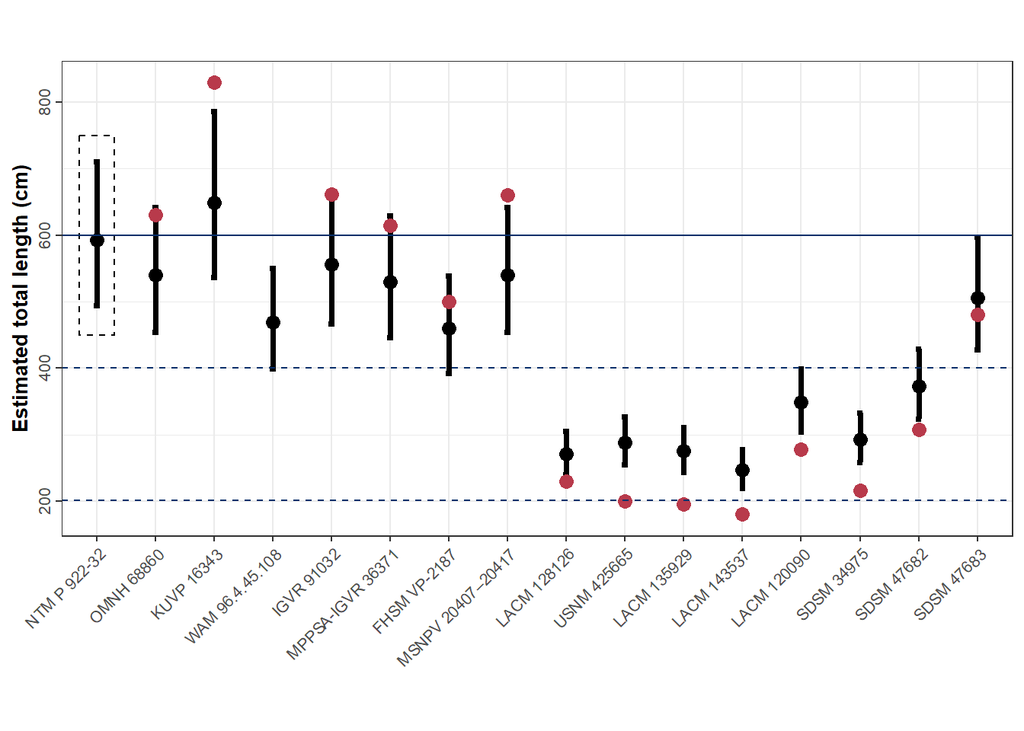

```r
# First use the regression equation by Gottfried et al. (1996) to confirm the result in Frederickson et al. 2015.
# The CD here is in mm units and result in m.

# 0.22 + 0.058 * 110

# Use Lamnidae interspecific model to re-estimate the TL.

# 10^predict(object = interSM4,newdata = data.frame(log_cd = log10(11.0)),interval = "prediction")
# 10^predict(object = interSM4,newdata = data.frame(log_cd = log10(8.7)), interval = "prediction")

# Cretaceous lamniform species.
stem_species <-
  data.frame(log_cd = log10(mesozoic_data$centrum_diameter/10))

10^predict(object = interSM3,newdata = stem_species,interval = "prediction") |>
  data.frame() |>
  add_column("specimen" = mesozoic_data$label) |>
  mutate(CD= mesozoic_data$centrum_diameter/10) |>
  add_row(fit = 592.5426, lwr = 493.8996, upr = 710.8868,specimen = "NTM P 922-32", CD = 12.6) |>
  # Order by age
  mutate(specimen = factor(specimen, levels = c("NTM P 922-32","OMNH 68860","KUVP 16343","WAM 96.4.45.108",
                                                "MMSP CPC 3063","MMSP CPC 3068",
                                                "IGVR 91032","MPPSA-IGVR 36371","FHSM VP-2187","MSNPV 20407–20417",
                                                "LACM 128126","USNM 425665","LACM 135929","LACM 143537",
                                                "LACM 120090","SDSM 34975","SDSM 47682","SDSM 47683"))) |>
  ggplot(aes(x = specimen, y = fit)) +
  geom_errorbar(aes(ymin = lwr, ymax = upr),
                width = 0.1,linewidth = 1.3) +
  geom_point(size = 3, shape = 19,colour = "black") +
  # Original points.
  geom_point(data = mesozoic_data,aes(x = label, y = total_length/10), size = 3, shape = 19, colour = "#B83A4B") +
  # CD label.
  #geom_text(aes(x = specimen, y = fit + 200, label = paste0("CD=",as.character(CD),"cm")),size = 6, col = "black") +
  geom_rect(xmin = 0.7, xmax = 1.3, ymin = 450, ymax = 750,lty = 2,alpha = 0, color = "black") +
  # ‘small,’ 1‒200 cm; ‘medium,’ 201‒400 cm; ‘large,’ 401‒600 cm; and ‘gigantic,’ >600 cm).
  geom_hline(yintercept = c(201,400,600), lty = c(2,2,1), col = "#08306b") +
  theme_bw() +
  labs(x = NULL, y = "Estimated total length (cm)",title = NULL) +
  theme(title = element_text(face = "bold"),
        axis.title = element_text(face = "bold",size = 10),
        axis.text = element_text(size = 8),
        axis.text.x = element_text(hjust = 1,vjust = 1,angle = 45),
        axis.text.y = element_text(angle = 90,hjust = 0.5,vjust = 0.5),
        legend.title = element_text(face = "bold"),
        plot.title = element_text(face = "bold",size = 12),
        aspect.ratio = 1/2)
```

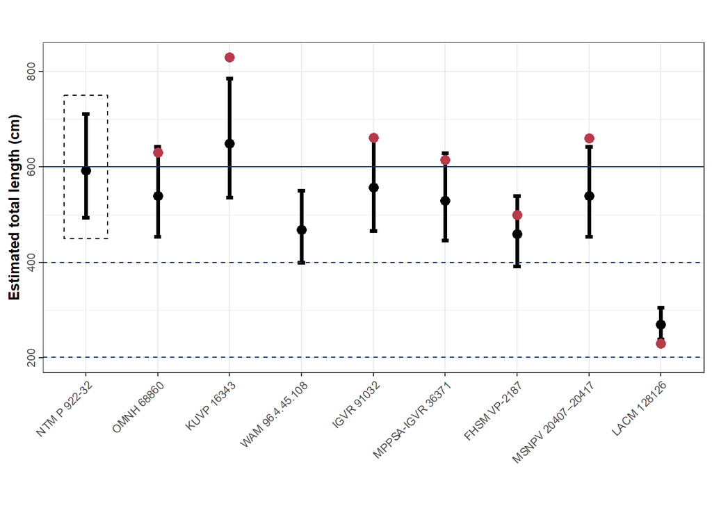

```r
# Exclude Anacoracids.
10^predict(object = interSM3,newdata = stem_species,interval = "prediction") |>
  data.frame() |>
  add_column("specimen" = mesozoic_data$label) |>
  mutate(CD= mesozoic_data$centrum_diameter/10) |>
  add_row(fit = 592.5426, lwr = 493.8996, upr = 710.8868,specimen = "NTM P 922-32", CD = 12.6) |>
  as_tibble() |>
  # Anacoracidae
  filter(!specimen %in% c("USNM 425665","LACM 135929","LACM 143537", "LACM 120090", "SDSM 34975", "SDSM 47682", "SDSM 47683")) |>
  # Order by Age,
  mutate(specimen = factor(specimen, levels = c("NTM P 922-32",
                                                "OMNH 68860",
                                                "KUVP 16343",
                                                "WAM 96.4.45.108",
                                                "IGVR 91032",
                                                "MPPSA-IGVR 36371",
                                                "FHSM VP-2187",
                                                "MSNPV 20407–20417",
                                                "LACM 128126"))) |>
  ggplot(aes(x = specimen, y = fit)) +
  geom_errorbar(aes(ymin = lwr, ymax = upr),
                width = 0.1,linewidth = 1.3) +
  geom_point(size = 3, shape = 19,colour = "black") +
  # Original points.
  geom_point(data = mesozoic_data |> filter(family != "Anacoracidae"),aes(x = label, y = total_length/10), size = 3, shape = 19, colour = "#B83A4B") +
  # CD label.
  #geom_text(aes(x = specimen, y = fit + 200, label = paste0("CD=",as.character(CD),"cm")),size = 6, col = "black") +
  geom_rect(xmin = 0.7, xmax = 1.3, ymin = 450, ymax = 750,lty = 2,alpha = 0, color = "black") +
  # ‘small,’ 1‒200 cm; ‘medium,’ 201‒400 cm; ‘large,’ 401‒600 cm; and ‘gigantic,’ >600 cm).
  geom_hline(yintercept = c(201,400,600), lty = c(2,2,1), col = "#08306b") +
  theme_bw() +
  labs(x = NULL, y = "Estimated total length (cm)",title = NULL) +
  theme(title = element_text(face = "bold"),
        axis.title = element_text(face = "bold",size = 10),
        axis.text = element_text(size = 8),
        axis.text.x = element_text(hjust = 1,vjust = 1,angle = 45),
        axis.text.y = element_text(angle = 90,hjust = 0.5,vjust = 0.5),
        legend.title = element_text(face = "bold"),
        plot.title = element_text(face = "bold",size = 12),
        aspect.ratio = 1/2)
```

**IRSNB 3121**

```r
# Carcharocles megalodon.
cooper_megladon <-
  openxlsx::read.xlsx(xlsxFile = "data/Cooper et al. 2022.xlsx",sheet = 1) |>
  rename("Diameter" = 9) |>
  mutate(Diameter = Diameter/10) |>
  mutate(log_cd = log10(Diameter)) |>
  dplyr::select(log_cd)

# Predictions (using C. carcharias as the reference)
meg_fit1 <-
  10^predict(object = length_linear_fit_ols,newdata = data.frame(log_cd = cooper_megladon$log_cd),interval = "prediction") |>
  as.data.frame() |>
  ggplot(aes(x = 1:141,y = fit)) +
  geom_errorbar(aes(ymin = lwr, ymax = upr), color = "#014240") +
  geom_point(color = "#014240", fill = "white", shape = 21) +
  scale_y_continuous(limits = c(100,1200)) +
  geom_hline(yintercept = c(920,1110), linewidth = 1.2,
             color = c("#CA0020","#5D4B3C")) +
  labs(x = "Vertebrae (IRSNB 3121)", y = "Total length (TL, cm)",
       title = "Otodus megalodon",
       subtitle = "C. carcharias as the reference species",
       caption = "") +
  theme_bw() +
  theme(plot.title = element_text(face = "bold.italic"),
        axis.title = element_text(face = "bold"),
        axis.text.y = element_text(angle = 90,hjust = 1,vjust = 1),
        aspect.ratio = 1)

round(100 - (1021.1817/100)/11.1 * 100,digits = 2) # 8% difference between regression-model estimate and minimum column length of 11.1 m.

# Predictions (using Lamnna nasus as the reference)
meg_fit2 <-
  10^predict(object = slope_intercept$model[[9]],newdata = data.frame(log_cd = cooper_megladon$log_cd),interval = "prediction") |>
  as.data.frame() |>
  ggplot(aes(x = 1:141,y = fit)) +
  geom_errorbar(aes(ymin = lwr, ymax = upr), color = "#014240") +
  geom_point(color = "#014240", fill = "white", shape = 21) +
  scale_y_continuous(limits = c(100,1200)) +
  geom_hline(yintercept = c(1110), linewidth = 1.2,
             color = c("#5D4B3C")) +
  labs(x = "Vertebrae (IRSNB 3121)", y = "Total length (TL, cm)",
       title = "Otodus megalodon",
       subtitle = "Lamna nasus as the reference species",
       caption = "") +
  theme_bw() +
  theme(plot.title = element_text(face = "bold.italic"),
        axis.title = element_text(face = "bold"),
        axis.text.y = element_text(angle = 90,hjust = 1,vjust = 1),
        aspect.ratio = 1)

# Predictions (using interspecific model)
meg_fit3 <-
  10^predict(object = interSM3,newdata = data.frame(log_cd = cooper_megladon$log_cd),interval = "prediction") |>
  as.data.frame() |>
  ggplot(aes(x = 1:141,y = fit)) +
  geom_errorbar(aes(ymin = lwr, ymax = upr), color = "#08306b") +
  geom_point(color = "#08306b", fill = "white", shape = 21) +
  scale_y_continuous(limits = c(100,1200)) +
  geom_hline(yintercept = c(1110), linewidth = 1.2,
             color = c("#B2182B")) +
  labs(x = "Vertebrae (IRSNB 3121)", y = "Total length (TL, cm)",
       title = "Otodus megalodon",
       subtitle = "",
       caption = "") +
  theme_bw() +
  theme(plot.title = element_text(face = "bold.italic"),
        axis.title = element_text(face = "bold"),
        axis.text.y = element_text(angle = 90,hjust = 1,vjust = 1),
        aspect.ratio = 1)
```

## Body size evolution

```r
shimada <-
  openxlsx::read.xlsx(xlsxFile = "data/Shimada et al. 2021.xlsx") |>
  mutate(TL = as.numeric(TL),
         Min = as.numeric(Min),
         Max = as.numeric(Max))

bzE <- ggplot(shimada) +
  geom_segment(aes(x = Min, xend = Max, y = Genus, yend = Genus), linewidth = 1) +
  # geom_point(aes(x = (Min + Max) / 2, y = Genus, size = TL), color = "red")
  geom_point(aes(x = (Min + Max) / 2, y = Genus, size = TL, color = TL >= 500), show.legend = T) +
  scale_color_manual(values = c("#006B81", "#B83A4B")) +
  labs(title = "Lamniform body size evolution", subtitle = "Estimated maximum possible total body length", x = "Geological Age (Ma)", y = NULL) +
  # geom_vline(xintercept = c(149.2,145.0,139.8,132.6,125.77,121.4,113.0,100.5,93.9,89.8,86.3,83.6,72.1,66.0,61.6,59.2,56.0,47.8,41.2,37.71,33.9,
  #                           27.82,23.03,20.44,15.98,13.82,11.63,7.246,5.333,3.600,2.58,1.80,0.774,0.129,0.0117,0.0), col = "black") +
  # geom_vline(xintercept = c(145.0,100.5,66.0,56.0,33.9,23.03,5.333,2.58,0.0117), col = "red") +
  geom_vline(xintercept = 66.0, col = "red") +
  theme_bw() +
  theme(plot.title = element_text(face = "bold"),
        axis.text.y = element_text(face = "italic"),
        axis.title = element_text(face = "bold"))

bzEe <- shimada |>
  filter(TL >= 450) |>
  ggplot() +
  geom_segment(aes(x = Min, xend = Max, y = Genus, yend = Genus), linewidth = 1) +
  geom_point(aes(x = (Min + Max) / 2, y = Genus, size = TL), color = "red") +
  labs(title = "Lamniform body size evolution", subtitle = "Estimated maximum possible total body length", x = "Geological Age (Ma)", y = NULL) +
  theme_bw() +
  theme(plot.title = element_text(face = "bold"),
        axis.text = element_text(face = "bold"),
        axis.title = element_text(face = "bold"))
```

## Statement on data use

The data used in this study was compiled from multiple sources and future use, whether in part or whole, should cite and credit the original work.

## References

Cailliet, G. M., L. K. Martin, D. Harvey J. T. Kusher, and B. A. Welden. 1983. “Preliminary Studies on the Age and Growth of Blue (Prionace Glauca), Common Thresher (Alopias Vulpinus), and Shortfin Mako (Isurus Oxyrinchus) Sharks from California Waters.” *In Proceedings International Workshop on Age Determination of Oceanic Pelagic Fishes: Tunas, Billfishes, Sharks, ED Prince and LM Pulos, Eds., NOAA Tech. Rep.* 8: 179–88.

Cailliet, G. M., L. J. Natanson, B. A. Welden, and D. A. Ebert. 1985. “Preliminary Studies on the Age and Growth of the White Shark, Carcharodon Carcharias, Using Vertebral Bands.” *Memoirs of the Southern California Academy of Sciences* 9 (4): 49–60.

Drew, M., W. T. White, A. V. Dharmadi Harry, and C. Huveneers. 2015. “Age, Growth and Maturity of the Pelagic Thresher Alopias Pelagicus and the Scalloped Hammerhead Sphyrna Lewini.” *Journal of Fish Biology* 86 (1): 333–54.

Frederickson, J. A., S. N. Schaefer, and J. A. Doucette-Frederickson. 2015. “A Gigantic Shark from the Lower Cretaceous Duck Creek Formation of Texas.” *PLoS One* 10: p.e0127162.

Goldman, K. J., and J. A. Musick. 2006. “Growth and Maturity of Salmon Sharks (Lamna Ditropis) in the Eastern and Western North Pacific, and Comments on Back-Calculation Methods.” *Fishery Bulletin* 104: 278–92.

Hansen, B. B., G. Cuny, B. W. Rasmussen, K. Shimada, P. Jacobs, and C. Heilmann-Clausen. 2013. “Associated Skeletal and Dental Remains of a Fossil Odontaspidid Shark (Elasmobranchii: Lamniformes) from the Middle Eocene Lillebælt Clay Formation in Denmark.” *Bulletin of the Geological Society of Denmark* 61: 37–46.

Kindong, R., H. Wang, F. Wu, X. Dai, and S. Tian. 1998. “Age, Growth, and Sexual Maturity of the Crocodile Shark, Pseudocarcharias Kamoharai, from the Eastern Atlantic Ocean.” *Frontiers in Marine Science* 7: 586024.

Liu, K. M., C. T. Chen, T. H. Liao, and S. J. Joung. 1999. “Age, Growth, and Reproduction of the Pelagic Thresher Shark, Alopias Pelagicus in the Northwestern Pacific.” *Copeia*, 68–74.

Liu, K. M., P. J. Chiang, and C. T. Chen. 1998. “Age and Growth Estimates of the Bigeye Thresher Shark, Alopias Superciliosus, in Northeastern Taiwan Waters.” *Fishery Bulletin* 96: 482–91.

Lucifora, L. O. 2003. “Ecología y Conservación de Los Grandes Tiburones Costeros de Bahía Anegada, Provincia de Buenos Aires, Argentina.” *Theses and Dissertations*.

Natanson, L. J., N. E. Kohler, D. Ardizzone, G. M. Cailliet, S. P. Wintner, and H. F. Mollet. 2002. “Validated Age and Growth Estimates for the Shortfin Mako, Isurus Oxyrinchus, in the North Atlantic Ocean.” *Special Issue: Age and Growth of Chondrichthyan Fishes: New Methods, Techniques and Analysis*, 367–83.

Natanson, L. J., J. J. Mello, and S. E. Campana. 2002. “Validated Age and Growth of the Porbeagle Shark (Lamna Nasus) in the Western North Atlantic Ocean.” *Fishery Bulletin* 100: 266–78.

Natanson, L. J., G. B. Skomal, S. L. Hoffmann, M. E. Porter, K. J. Goldman, and D. Serra. 1998. “Age and Growth of Sharks: Do Vertebral Band Pairs Record Age?” *Marine and Freshwater Research* 69 (9): 1440–52.

Natanson, L. J., S. P. Wintner, F. Johansson, A. Piercy, P. Campbell, A. De Maddalena, S. J. B. Gulak, et al. 2008. “Ontogenetic Vertebral Growth Patterns in the Basking Shark Cetorhinus Maximus.” *Marine Ecology Progress Series* 361: 267–78.

Shimada, K. 1997. “Skeletal Anatomy of the Late Cretaceous Lamniform Shark, Cretoxyrhina Mantelli from the Niobrara Chalk in Kansas.” *Journal of Vertebrate Paleontology* 17: 642–52.

Stone, N. R., and K. Shimada. 2019. “Skeletal Anatomy of the Bigeye Sand Tiger Shark, Odontaspis Noronhai (Lamniformes: Odontaspididae), and Its Implications for Lamniform Phylogeny, Taxonomy, and Conservation Biology.” *Copeia* 107 (4): 632–52.